# CS555 - Project

This is my CS555 Project on Hosuing Project

1. longitude: A measure of how far west a house is; a higher value is farther west
2. latitude: A measure of how far north a house is; a higher value is farther north
3. housingMedianAge: Median age of a house within a block; a lower number is a newer building
4. totalRooms: Total number of rooms within a block
5. totalBedrooms: Total number of bedrooms within a block
6. population: Total number of people residing within a block
7. households: Total number of households, a group of people residing within a home unit, for a block
8. medianIncome: Median income for households within a block of houses (measured in tens of thousands of US Dollars)
9. medianHouseValue: Median house value for households within a block (measured in US Dollars)
10. oceanProximity: Location of the house w.r.t ocean/sea

```r
libarary(tidyverse)
```

[output not shown]

After reading the data, I will do some basic pre-processing. This step is necessary to clean up the data since our dataset is large. We will reduce the dataset to no more than 2000 observations. Upon closer inspection, the dataset contains 20,640 rows. This is seen below on the Rows.

```r
glimpse(housing_data)
```

```
Rows: 20,640
Columns: 10
$ longitude          <dbl> -122.23, -122.22, -122.24, -122.25, -122.25, -122.25, -122.25, -122.25, -122.26, -122.25, -122.26, -122.26, -122.26,…
$ latitude           <dbl> 37.88, 37.86, 37.85, 37.85, 37.85, 37.85, 37.84, 37.84, 37.84, 37.84, 37.85, 37.85, 37.85, 37.84, 37.85, 37.85, 37.8…
$ housing_median_age <dbl> 41, 21, 52, 52, 52, 52, 52, 52, 42, 52, 52, 52, 52, 52, 52, 50, 52, 52, 50, 52, 40, 42, 52, 52, 52, 41, 49, 52, 50, …
$ total_rooms        <dbl> 880, 7099, 1467, 1274, 1627, 919, 2535, 3104, 2555, 3549, 2202, 3503, 2491, 696, 2643, 1120, 1966, 1228, 2239, 1503,…
$ total_bedrooms     <dbl> 129, 1106, 190, 235, 280, 213, 489, 687, 665, 707, 434, 752, 474, 191, 626, 283, 347, 293, 455, 298, 184, 367, 541, …
$ population         <dbl> 322, 2401, 496, 558, 565, 413, 1094, 1157, 1206, 1551, 910, 1504, 1098, 345, 1212, 697, 793, 648, 990, 690, 409, 929…
$ households         <dbl> 126, 1138, 177, 219, 259, 193, 514, 647, 595, 714, 402, 734, 468, 174, 620, 264, 331, 303, 419, 275, 166, 366, 478, …
$ median_income      <dbl> 8.3252, 8.3014, 7.2574, 5.6431, 3.8462, 4.0368, 3.6591, 3.1200, 2.0804, 3.6912, 3.2031, 3.2705, 3.0750, 2.6736, 1.91…
$ median_house_value <dbl> 452600, 358500, 352100, 341300, 342200, 269700, 299200, 241400, 226700, 261100, 281500, 241800, 213500, 191300, 1592…
$ ocean_proximity    <chr> "NEAR BAY", "NEAR BAY", "NEAR BAY", "NEAR BAY", "NEAR BAY", "NEAR BAY", "NEAR BAY", "NEAR BAY", "NEAR BAY", "NEAR BA…
```

One of the ways we can reduce the dataset is through random sampling. This is basically choosing random samples without replacement from the dataset. Before doing that, we can start by seeing whether there are missing values in our datasets.

```r
library(ggplot2)
library(dplyr)
library(visdat)
summary(data)
```

```
   longitude         latitude     housing_median_age  total_rooms    total_bedrooms     population      households     median_income
 Min.   :-124.3   Min.   :32.54   Min.   : 1.00      Min.   :    2   Min.   :   1.0   Min.   :    3   Min.   :   1.0   Min.   : 0.4999
 1st Qu.:-121.8   1st Qu.:33.93   1st Qu.:18.00      1st Qu.: 1448   1st Qu.: 296.0   1st Qu.:  787   1st Qu.: 280.0   1st Qu.: 2.5634
 Median :-118.5   Median :34.26   Median :29.00      Median : 2127   Median : 435.0   Median : 1166   Median : 409.0   Median : 3.5348
 Mean   :-119.6   Mean   :35.63   Mean   :28.64      Mean   : 2636   Mean   : 537.9   Mean   : 1425   Mean   : 499.5   Mean   : 3.8707
 3rd Qu.:-118.0   3rd Qu.:37.71   3rd Qu.:37.00      3rd Qu.: 3148   3rd Qu.: 647.0   3rd Qu.: 1725   3rd Qu.: 605.0   3rd Qu.: 4.7432
 Max.   :-114.3   Max.   :41.95   Max.   :52.00      Max.   :39320   Max.   :6445.0   Max.   :35682   Max.   :6082.0   Max.   :15.0001
                                                                     NA's   :207
 median_house_value ocean_proximity
 Min.   : 14999     Length:20640
 1st Qu.:119600     Class :character
 Median :179700     Mode  :character
 Mean   :206856
 3rd Qu.:264725
 Max.   :500001
```

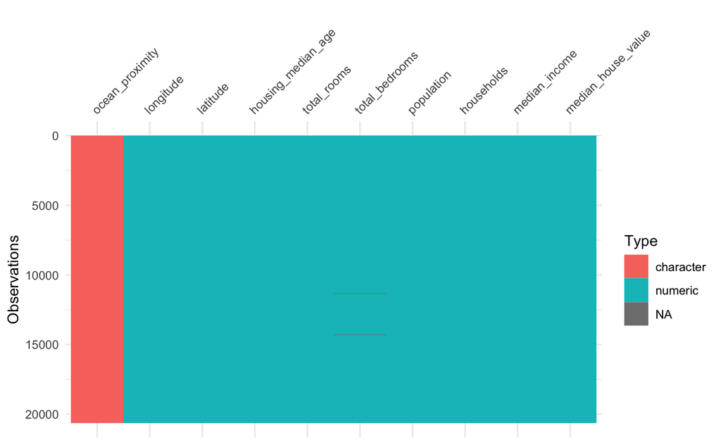

```r
vis_dat(data)
```

We can see that there are 207 missing values in the total_bedrooms variables. We can also see, through the visualization, that most of the data is complete except those 207 rows of bedrooms. It’s worth noting that we can’t completely remove them as they might hold some insights (If all the total_bedrooms are of a certain building type than maybe we can’t remove them). So now, we will look and delve deeper at those missing values.

|  | longitude | latitude | housing_median_age | total_rooms | total_bedrooms | population | households | median_income | median_house_value | ocean_proximity |
| --- | --- | --- | --- | --- | --- | --- | --- | --- | --- | --- |
| 291 | -122.16 | 37.77 | 47 | 1256 | NA | 570 | 218 | 4.3750 | 161900 | NEAR BAY |
| 342 | -122.17 | 37.75 | 38 | 992 | NA | 732 | 259 | 1.6196 | 85100 | NEAR BAY |
| 539 | -122.28 | 37.78 | 29 | 5154 | NA | 3741 | 1273 | 2.5762 | 173400 | NEAR BAY |
| 564 | -122.24 | 37.75 | 45 | 891 | NA | 384 | 146 | 4.9489 | 247100 | NEAR BAY |
| 697 | -122.10 | 37.69 | 41 | 746 | NA | 387 | 161 | 3.9063 | 178400 | NEAR BAY |
| 739 | -122.14 | 37.67 | 37 | 3342 | NA | 1635 | 557 | 4.7933 | 186900 | NEAR BAY |
| 1098 | -121.77 | 39.66 | 20 | 3759 | NA | 1705 | 600 | 4.7120 | 158600 | INLAND |
| 1351 | -121.95 | 38.03 | 5 | 5526 | NA | 3207 | 1012 | 4.0767 | 143100 | INLAND |
| 1457 | -121.98 | 37.96 | 22 | 2987 | NA | 1420 | 540 | 3.6500 | 204100 | INLAND |
| 1494 | -122.01 | 37.94 | 23 | 3741 | NA | 1339 | 499 | 6.7061 | 322300 | NEAR BAY |

[output cut: 197 more lines]

Here we have carefully selected the data where the total bedrooms have missing values.

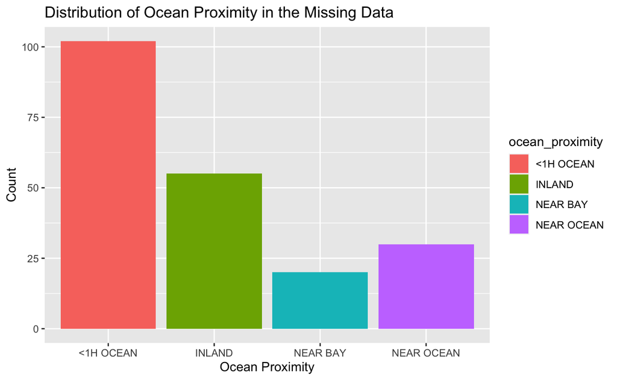

Comparing the Ocean Proximity distribution with the full dataset.

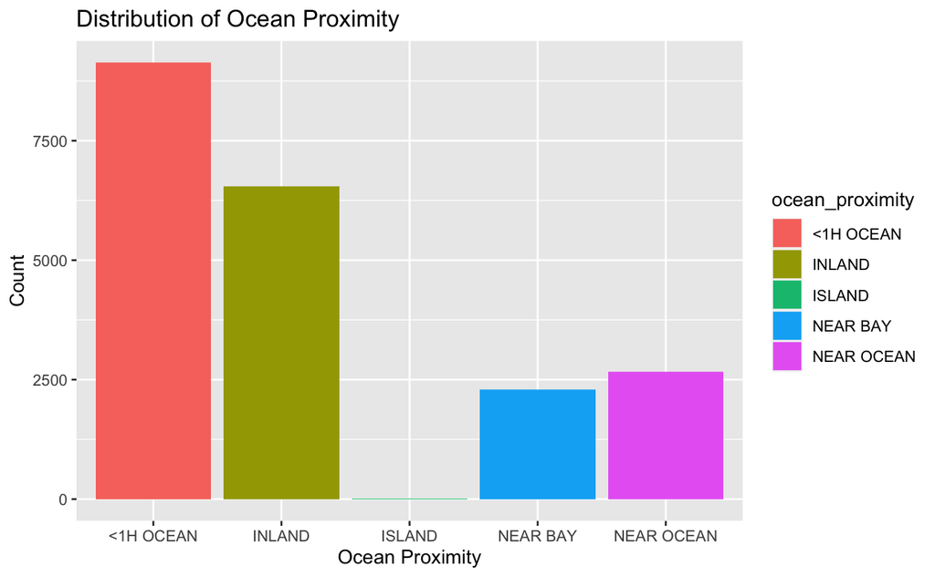

It doesn’t seem like there is an indication that the missing data is biased towards our variable of interest, ocean_proximity, and because of that we are going to remove all the missing data and proceed with the random sampling.

|  | longitude | latitude | housing_median_age | total_rooms | total_bedrooms | population | households | median_income | median_house_value | ocean_proximity |
| --- | --- | --- | --- | --- | --- | --- | --- | --- | --- | --- |
| 1 | -122.23 | 37.88 | 41 | 880 | 129 | 322 | 126 | 8.3252 | 452600 | NEAR BAY |
| 2 | -122.22 | 37.86 | 21 | 7099 | 1106 | 2401 | 1138 | 8.3014 | 358500 | NEAR BAY |
| 3 | -122.24 | 37.85 | 52 | 1467 | 190 | 496 | 177 | 7.2574 | 352100 | NEAR BAY |
| 4 | -122.25 | 37.85 | 52 | 1274 | 235 | 558 | 219 | 5.6431 | 341300 | NEAR BAY |
| 5 | -122.25 | 37.85 | 52 | 1627 | 280 | 565 | 259 | 3.8462 | 342200 | NEAR BAY |
| 6 | -122.25 | 37.85 | 52 | 919 | 213 | 413 | 193 | 4.0368 | 269700 | NEAR BAY |
| 7 | -122.25 | 37.84 | 52 | 2535 | 489 | 1094 | 514 | 3.6591 | 299200 | NEAR BAY |
| 8 | -122.25 | 37.84 | 52 | 3104 | 687 | 1157 | 647 | 3.1200 | 241400 | NEAR BAY |
| 9 | -122.26 | 37.84 | 42 | 2555 | 665 | 1206 | 595 | 2.0804 | 226700 | NEAR BAY |
| 10 | -122.25 | 37.84 | 52 | 3549 | 707 | 1551 | 714 | 3.6912 | 261100 | NEAR BAY |

[output cut: 990 more lines]

Simple Random Sampling without replacement

```r
library(sampling)
set.seed(42)
sample <- srswor(2000, dim(non_missing_val)[1])
rows <- (1:nrow(non_missing_val))[sample!=0]
rows <- rep(rows, sample[sample != 0])
sample.data <- non_missing_val[rows, ]
sample.data
```

|  | longitude | latitude | housing_median_age | total_rooms | total_bedrooms | population | households | median_income | median_house_value | ocean_proximity |
| --- | --- | --- | --- | --- | --- | --- | --- | --- | --- | --- |
| 2 | -122.22 | 37.86 | 21 | 7099 | 1106 | 2401 | 1138 | 8.3014 | 358500 | NEAR BAY |
| 16 | -122.26 | 37.85 | 50 | 1120 | 283 | 697 | 264 | 2.1250 | 140000 | NEAR BAY |
| 25 | -122.27 | 37.84 | 52 | 2224 | 437 | 1006 | 422 | 2.6000 | 132600 | NEAR BAY |
| 27 | -122.28 | 37.85 | 49 | 1130 | 244 | 607 | 239 | 2.4597 | 93800 | NEAR BAY |
| 69 | -122.30 | 37.81 | 52 | 572 | 109 | 274 | 82 | 1.8516 | 85000 | NEAR BAY |
| 73 | -122.29 | 37.81 | 49 | 844 | 204 | 560 | 152 | 1.7500 | 75000 | NEAR BAY |
| 84 | -122.28 | 37.81 | 52 | 386 | 164 | 346 | 155 | 0.8075 | 137500 | NEAR BAY |
| 91 | -122.27 | 37.80 | 16 | 994 | 392 | 800 | 362 | 2.0938 | 162500 | NEAR BAY |
| 92 | -122.28 | 37.80 | 52 | 215 | 87 | 904 | 88 | 0.8668 | 137500 | NEAR BAY |
| 94 | -122.27 | 37.79 | 27 | 1055 | 347 | 718 | 302 | 2.6354 | 187500 | NEAR BAY |

[output cut: 990 more lines]

Here, we managed to obtains 2000 random sample without replacement using the sampling library and we know that there are no missing data in our graph. We can start visualizing different components of our graph.

```r
ggplot(data = sample.data, aes(x = ocean_proximity, fill = ocean_proximity)) + geom_bar() +xlab('Ocean Proximity') + ylab('Count') + ggtitle('Distribution of Ocean Proximity')
```

[output not shown]

```r
round(corr_mat,2)
```

```
                   housing_median_age total_rooms total_bedrooms population households median_income median_house_value
housing_median_age               1.00       -0.36          -0.31      -0.30      -0.30         -0.14               0.10
total_rooms                     -0.36        1.00           0.92       0.87       0.91          0.21               0.14
total_bedrooms                  -0.31        0.92           1.00       0.89       0.99         -0.01               0.05
population                      -0.30        0.87           0.89       1.00       0.91          0.02              -0.01
households                      -0.30        0.91           0.99       0.91       1.00          0.01               0.07
median_income                   -0.14        0.21          -0.01       0.02       0.01          1.00               0.70
median_house_value               0.10        0.14           0.05      -0.01       0.07          0.70               1.00
```

Here, we also attempt to use the corrplot to show the correlation matrix.

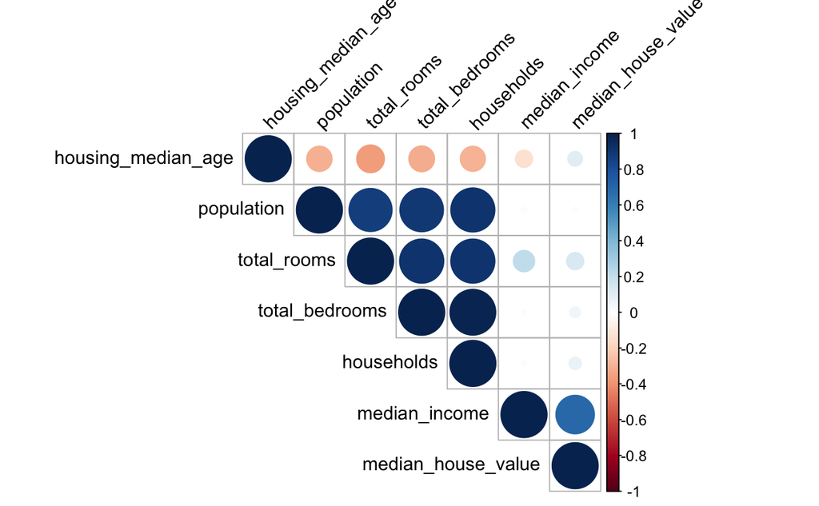

We now have an idea on how some of the data may or may not be correlated. My focus on this project is to perform linear regression and ANOVA on the ocean_proximity variable.

ANOVA on the ocean_proximity and it’s median_house_value

```r
summary(m1)
```

```
                   Df    Sum Sq   Mean Sq F value Pr(>F)
focean_proximity    4 7.008e+12 1.752e+12     165 <2e-16 ***
Residuals        1995 2.118e+13 1.062e+10
---
Signif. codes:  0 ‘***’ 0.001 ‘**’ 0.01 ‘*’ 0.05 ‘.’ 0.1 ‘ ’ 1
```

From our basic ANOVA analysis between ocean_proximity and median_house_value, we can see from the F value that we would reject the null hypothesis that all the different ocean_proximity have the same mean median_house_value.

```r
library(car)
Anova(lm(median_house_value~focean_proximity+total_bedrooms,data=sample.data), type=3)
```

```
Anova Table (Type III tests)

Response: median_house_value
                     Sum Sq   Df   F value  Pr(>F)
(Intercept)      2.7992e+13    1 2646.7053 < 2e-16 ***
focean_proximity 7.0142e+12    4  165.8003 < 2e-16 ***
total_bedrooms   9.0508e+10    1    8.5577 0.00348 **
Residuals        2.1089e+13 1994
---
Signif. codes:  0 ‘***’ 0.001 ‘**’ 0.01 ‘*’ 0.05 ‘.’ 0.1 ‘ ’ 1
```